# STAT6011 Assignment_1

Lee Lap San 3036373312 2025-10-06

## Question 1

### a

Let $\tilde{f}(x)=\exp(-\frac{x^2}{2})(\sin((4x)^2)+1)$. In addition, the pdf of a log-normal(0,1) distribution is $q(x) = \frac{1}{x \sqrt{2\pi}} \exp\left( -\frac{(\ln x)^2}{2} \right), \quad x > 0$. Using principles of importance sampling:
$$\frac{1}{k} = \int^5_0 \tilde{f}=\int_0^5 \frac{\tilde{f}}{q} \cdot q
=E_{X\sim q}[\frac{\tilde{f}(X)}{q(X)}\cdot I_{0<X<5}]$$
By Monte Carlo method of integral estimation:
$$\frac{1}{\hat{k}} = \frac{1}{n} \sum_{i=1}^n
\frac{\tilde{f}(x_i)}{q(x_i)}\cdot I(0<x_i<5),$$
where $x_i$ are samples from $q(x)$.

```r
# Set seed for reproducibility
set.seed(123)

# Define the target function ftil(x)
ftil <- function(x) {
  exp(-x^2 / 2) * (sin((4 * x)^2) + 1)
}

# Define the importance distribution q(x): LogNormal(0, 1)
q_density <- function(x) {
  dlnorm(x, meanlog = 0, sdlog = 1)
}

# Monte Carlo Importance Sampling Estimator for k
estimate_k <- function(N, x) {
  x <- rlnorm(N, meanlog = 0, sdlog = 1)
  f_vals <- ftil(x)
  q_vals <- q_density(x)
  weights <- f_vals / q_vals
  i05 <- ifelse(x > 0 & x < 5, 1, 0) # The indicator
  integral_estimate <- mean(weights*i05)
  k_estimate <- 1 / integral_estimate
  return(k_estimate)
}

# Run for different sample sizes
N_values <- c(1e3, 1e4, 1e5)
k_estimates <- sapply(N_values, estimate_k)


names(k_estimates) <- paste0("N = ", N_values)
print(k_estimates)
```

```
 N = 1000 N = 10000 N = 1e+05
0.7270576 0.7214524 0.7145359
```

### b

Use the `integrate` function in R:

```r
## b)

# Perform numerical integration over [0, 5]
result <- integrate(ftil, lower = 0, upper = 5)

# Extract the integral value
integral_value <- result$value

# Compute k = 1 / integral
k <- 1 / integral_value


cat("Numerical integration estimate of the integral:", integral_value, "\n", "Estimated value of k = 1 / integral:", k, "\n")
```

```
Numerical integration estimate of the integral: 1.407471
 Estimated value of k = 1 / integral: 0.710494
```

### c,d

Note $g(x) = \exp(-x)$. For rejection sampling, we need to find a $C$ such that
$$f(x) \leq C \cdot g(x) \quad \text{for all } x \in [0, 5],$$
which is equivalent, with $\tilde{C}=\frac{C}{k}$ as
$$\tilde{f}(x) \leq \tilde{C} \cdot g(x) \quad \text{for all } x \in [0,
5],$$
To maximize acceptance rate, we seek for the smallest $C$, which is equivalent as the optimization problem:
$$C = \sup_{x \in [0, 5]} \frac{f(x)}{g(x)} = \sup_{x \in [0, 5]} ke^{x -
\frac{x^2}{2}} \left( \sin((4x)^2) + 1 \right)$$
Since $k$ is not known in exact, we employ the following equation and seek for optimized $\tilde{C}$ instead of $C$.
$$\tilde{C} = \sup_{x \in [0, 5]} \frac{\tilde{f}(x)}{g(x)} = \sup_{x \in
[0, 5]} e^{x - \frac{x^2}{2}} \left( \sin((4x)^2) + 1 \right)$$
Note that $f(x)$ can be sampled without using estimates of $k$ in the rejection sampling algorithm, since $P(f(X) \leq C \cdot g(X))=P(\tilde{f}(X) \leq \tilde{C} \cdot g(X))$. In fact, if $h(x)=af(x)$ for some scalar $a$, then using $h(x)$ in place of $f(x)$ in the rejection algorithm will always generate samples distributed as the normalized $f(x)$, no matter what value $a$ takes, as long as a legal $C$ is used. The only estimate that enters into the rejection sampling algorithm is the estimate of $\tilde{C}$. We use the `optimize` function in R to estimate the optimized solution. An estimated value of $C$ is then given by $\hat{C}=\hat{k}\tilde{C}$, where $\hat{k}$ is the result of part b above.

```r
## c,d)

# Proposal distribution: g(x) = Exp(1)
g <- function(x) {
  dexp(x, rate = 1)
}

# Find optimal Ctil using numerical optimization
Ctil_result <- optimize(function(x) exp(x - x^2 / 2) * (sin((4 * x)^2) + 1),
                     interval = c(0, 5), maximum = TRUE)
Ctil <- Ctil_result$objective
C <- Ctil*k # Estimate C by the estimate of k

# Print optimal C
cat("Optimal value of tilde C for rejection sampling:", Ctil, "\n",
    "Estimated optimal value of C", C, "\n")
```

```
Optimal value of tilde C for rejection sampling: 2.604135
 Estimated optimal value of C 1.850222
```

We then apply rejection sampling algorithm directly with the estimated $\tilde{C}$ and $\tilde{f}$.

```r
# Rejection sampling function
rejection_sampler <- function(n) {
  samples <- numeric(0)
  attempts <- 0

  while (length(samples) < n) {
    x <- rexp(1, rate = 1)  # sample from proposal
    u <- runif(1)
    if (u <= ftil(x) / (Ctil * g(x))) {
      samples <- c(samples, x)
    }
    attempts <- attempts + 1
  }

  acceptance_rate <- n / attempts
  return(list(samples = samples, acceptance_rate = acceptance_rate))
}

# Generate 10^4 samples
result <- rejection_sampler(1e4)
samples <- result$samples
acceptance_rate <- result$acceptance_rate

# Print acceptance rate
cat("Acceptance rate:", acceptance_rate, "\n")
```

```
Acceptance rate: 0.5256518
```

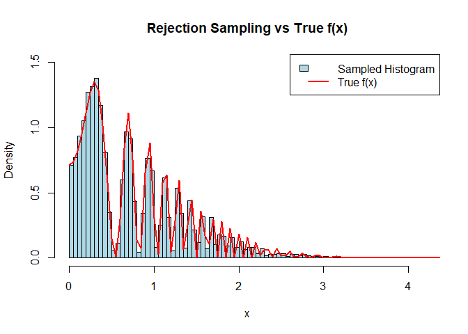

```r
# Plot histogram with y-axis scaled from 0 to 10
hist(samples, breaks = 100, probability = TRUE, col = "lightblue",
     main = "Rejection Sampling vs True f(x)", xlab = "x", ylim = c(0, 1.5))

# Overlay true f(x)
# Estimated true f(x) with k estimate
f <- function (x) {
  k*ftil(x)
}
curve(f(x), from = 0, to = 5, col = "red", lwd = 2, add = TRUE)

# Add legend
legend("topright", legend = c("Sampled Histogram", "True f(x)"),
       fill = c("lightblue", NA), border = c("black", NA),
       lty = c(NA, 1), col = c("black", "red"), lwd = c(NA, 2))
```

It can be seen that the sampled histogram is a good approximation of true $f(x)$.

### e

Since $k$ is not known in exact, we perform some neat tricks to eliminate it in our derivation of algorithms. Noting that $E_{X\sim f}[I_{0<X<5}]=1$:
$$P(X>3)=P(3<X<5)=E_{X\sim f}[I_{3<X<5}]=\frac{E_{X\sim
f}[I_{3<X<5}]}{E_{X\sim
f}[I_{0<X<5}]}=\frac{\int^5_3k\tilde{f}}{\int^5_0k\tilde{f}}=\frac{\int^5_3\tilde{f}}{\int^5_0\tilde{f}}=\frac{E_{Y\sim
q}[\frac{\tilde{f}(Y)}{q(Y)}\cdot I_{3<Y<5}]}{E_{Y\sim
q}[\frac{\tilde{f}(Y)}{q(Y)}\cdot I_{0<Y<5}]},$$
where the last equality results from the principles of importance sampling. We use the log-normal(0,1) distribution as the importance distribution as before. With $Y_i$ being iid log-noraml(0,1), Kolmogorov Strong Law of Large Numbers yields:
$$\frac{1}{n} \sum_{i=1}^n \frac{\tilde{f}(Y_i)}{q(Y_i)}\cdot
I_{3<Y_i<5} \xrightarrow{a.c.} E_{Y\sim
q}[\frac{\tilde{f}(Y)}{q(Y)}\cdot I_{3<Y<5}] \\
\frac{1}{n} \sum_{i=1}^n \frac{\tilde{f}(Y_i)}{q(Y_i)}\cdot
I_{0<Y_i<5} \xrightarrow{a.c.} E_{Y\sim
q}[\frac{\tilde{f}(Y)}{q(Y)}\cdot I_{0<Y<5}]$$
Thus,
$$\frac{\sum_{i=1}^n \frac{\tilde{f}(Y_i)}{q(Y_i)}\cdot
I_{3<Y_i<5}}{\sum_{i=1}^n \frac{\tilde{f}(Y_i)}{q(Y_i)}\cdot
I_{0<Y_i<5}} \xrightarrow{p} P(X>3)$$
We then use Monte Carlo method for estimation using realizations of samples $y_i$:
$$\widehat{P(X>3)} = \frac{\sum_{i=1}^n
\frac{\tilde{f}(y_i)}{q(y_i)}\cdot I_{3<y_i<5}}{\sum_{i=1}^n
\frac{\tilde{f}(y_i)}{q(y_i)}\cdot I_{0<y_i<5}}$$
To estimate confidence intervals, we also need the distribution of our estimate. Central limit theorem yields:
$$\frac{1}{n} \sum_{i=1}^n \frac{\tilde{f}(Y_i)}{q(Y_i)}\cdot
I_{3<Y_i<5} \xrightarrow{d} \mathcal{N}(E_{Y\sim
q}[\frac{\tilde{f}(Y)}{q(Y)}\cdot I_{3<Y<5}],
\frac{1}{n}Var_{Y\sim q}[\frac{\tilde{f}(Y)}{q(Y)}\cdot
I_{3<Y<5}]).$$
Then by Slusky’s theorem,
$$\frac{\sum_{i=1}^n \frac{\tilde{f}(Y_i)}{q(Y_i)}\cdot
I_{3<Y_i<5}}{\sum_{i=1}^n \frac{\tilde{f}(Y_i)}{q(Y_i)}\cdot
I_{0<Y_i<5}} \xrightarrow{d} \mathcal{N}(P(X>3),\frac{k^2}{n}
Var_{Y\sim q}[\frac{\tilde{f}(Y)}{q(Y)}\cdot I_{3<Y<5}]),$$
noting that $E_{Y\sim q}[\frac{\tilde{f}(Y)}{q(Y)}\cdot I_{0<Y<5}] =\int^5_0\tilde{f} = \frac{1}{k}$. The $Var(\cdot)$ part is estimated by sample variance $s^2$, treating each $w_i=\frac{\tilde{f}(y_i)}{q(y_i)}\cdot I(3<y_i<5)$ as a sample.

```r
## e)
N= 1e4
random_stream <- rlnorm(N, meanlog = 0, sdlog = 1)
f_vals <- ftil(random_stream)
q_vals <- q_density(random_stream)
weights <- f_vals / q_vals
i35 <- ifelse(random_stream > 3 & random_stream < 5, 1, 0) # The indicator
i05 <- ifelse(random_stream > 0 & random_stream < 5, 1, 0)

ratio_estimate <- sum(weights*i35)/sum(weights*i05)
variance_estimate <- var(weights*i35)/N*(k^2)
ci <- c(ratio_estimate + qnorm(0.05)*sqrt(variance_estimate), ratio_estimate + qnorm(0.95)*sqrt(variance_estimate))
cat("Numerical estimate of P(X>3):", ratio_estimate, "\n",
    "Variance estimate:", variance_estimate, "\n",
    "Approximate 90% CI: ", ci, "\n")
```

```
Numerical estimate of P(X>3): 0.002479366
 Variance estimate: 2.200955e-08
 Approximate 90% CI:  0.002235342 0.00272339
```

## Question 2

### a

The Jackknife method refers to the method of leave-one-out resampling as shown below.

```r
# Load data
data <- read.csv("Q2.csv")

# Extract X and Y
X <- data$X
Y <- data$Y
n <- length(X)
ground_truth <- 0.5

# Function to compute Pearson correlation
pearson_r <- function(x, y) {
  cor(x, y, method = "pearson")
}

# Jackknife estimates
jackknife_r <- numeric(n)

for (i in 1:n) {
  jackknife_r[i] <- pearson_r(X[-i], Y[-i])
}

# Jackknife estimate of correlation (mean of leave-one-out estimates)
r_jackknife <- mean(jackknife_r)

# Bias with respect to ground truth (ρ = 0.5)
bias <- r_jackknife - ground_truth

# Jackknife variance estimate
variance <- (n - 1) * mean((jackknife_r - r_jackknife)^2)

# Output results
cat("Jackknife estimate of Pearson's r:", r_jackknife, "\n",
    "Bias with respect to ρ = 0.5:", bias, "\n",
    "Jackknife variance estimate:", variance, "\n")
```

```
Jackknife estimate of Pearson's r: 0.4303054
 Bias with respect to ρ = 0.5: -0.06969461
 Jackknife variance estimate: 0.005112058
```

### b

Efron bootstrap uses resampling with replacement, as shown below. In theoretical terms, if we let $w_i$ be the proportion of times of $x_i$ appearing the original realized sample $\{x_i:1\leq i \leq n\}$ (so $w_i$ are constants), then the distribution of possible resamples, $\{x_j:1\leq j \leq n\}$, can be described by a pdf $f(\{x_j:1\leq j \leq n\}|\mathbf{w})$. The percentile method uses the empirical density estimate to estimate quantiles for confidence interval construction, while the normal distribution methods rely on the asymptotic normal distribution guaranteed by central limit theorem for confidence interval construction from mean and variance.

```r
## b)
B <- 10000

# Bootstrap sampling
set.seed(123)  # for reproducibility
bootstrap_r <- numeric(B)

for (b in 1:B) {
  indices <- sample(1:n, size = n, replace = TRUE)
  bootstrap_r[b] <- cor(X[indices], Y[indices])
}

# Bootstrap estimate (mean of bootstrap samples)
r_bootstrap <- mean(bootstrap_r)

# Bias
bias <- r_bootstrap - ground_truth

# Variance
variance <- var(bootstrap_r)

# 95% CI - Normal approximation
se <- sqrt(variance)
ci_normal <- c(r_bootstrap + qnorm(0.025) * se, r_bootstrap + qnorm(0.975) * se)

# 95% CI - Percentile method
ci_percentile <- quantile(bootstrap_r, probs = c(0.025, 0.975))

# Output results
cat("Bootstrap estimate of Pearson's r:", r_bootstrap, "\n",
    "Bias with respect to ρ = 0.5:", bias, "\n",
    "Bootstrap variance estimate:", variance, "\n",
    "95% CI (Normal Approximation):", ci_normal, "\n",
    "95% CI (Percentile Method):", ci_percentile, "\n")
```

```
Bootstrap estimate of Pearson's r: 0.4305956
 Bias with respect to ρ = 0.5: -0.06940439
 Bootstrap variance estimate: 0.004940751
 95% CI (Normal Approximation): 0.2928288 0.5683624
 95% CI (Percentile Method): 0.2871496 0.5617832
```

### c

Comparing to the Efron’s approach, Bayesian approach treats $\mathbf{w}$ as a random variable instead of a constant. The first approach below first realize a sample of $\mathbf{w}^{(b)}$ for every bootstrap replication $b$, and estimate $\rho_{X,Y}$ by $\frac{1}{B}\sum_{b=1}^B \hat{\rho}((\mathbf{x},\mathbf{y}),\mathbf{w}^{(b)})$, where $\hat{\rho}((\mathbf{x},\mathbf{y}),\mathbf{w}^{(b)})$ is the weighted form of correlation coefficient. The second approach produces bootstrap samples $(\mathbf{x},\mathbf{y})^{(b)}$ from $\mathbf{w}^{(b)}$, and estimate $\rho_{X,Y}$ by $\frac{1}{B}\sum_{b=1}^B \hat{\rho}((\mathbf{x},\mathbf{y})^{(b)})$, where $\hat{\rho}((\mathbf{x},\mathbf{y})^{(b)})$ is the correlation coefficient applied on the bootstrap sample $(\mathbf{x},\mathbf{y})^{(b)}$.

```r
## c)
# Storage for bootstrap estimates
rho_bayes1 <- numeric(B)

set.seed(123)
for (b in 1:B) {
  # Draw n-1 uniform samples and sort
  a <- sort(runif(n - 1))
  a <- c(0, a, 1)
  w <- diff(a)  # weights: w_i = a_i - a_{i-1}

  # Weighted correlation
  mx <- sum(w * X)
  my <- sum(w * Y)
  cov_xy <- sum(w * (X - mx) * (Y - my))
  sd_x <- sqrt(sum(w * (X - mx)^2))
  sd_y <- sqrt(sum(w * (Y - my)^2))
  rho_bayes1[b] <- cov_xy / (sd_x * sd_y)
}

# Posterior summary
mean_rho1 <- mean(rho_bayes1)
var_rho1 <- var(rho_bayes1)
bias1 <- mean_rho1 - ground_truth
ci1 <- quantile(rho_bayes1, probs = c(0.025, 0.975))

cat("Version 1 (Weighted):\n",
    "Estimate:", mean_rho1, "\n",
    "Bias:", bias1, "\n",
    "Posterior Variance:", var_rho1, "\n",
    "95% Credible Interval:", ci1, "\n")
```

```
Version 1 (Weighted):
 Estimate: 0.4293386
 Bias: -0.07066144
 Posterior Variance: 0.004733064
 95% Credible Interval: 0.2861499 0.5564105
```

```r
# Storage for bootstrap estimates
rho_bayes2 <- numeric(B)

for (b in 1:B) {
  # Draw n-1 uniform samples and sort
  a <- sort(runif(n - 1))
  a <- c(0, a, 1)

  # Generate n samples by drawing u ~ Unif(0,1) and selecting (X[i], Y[i]) where ai-1 < u < ai
  u <- runif(n)
  indices <- findInterval(u, a, rightmost.closed = TRUE)

  # Resampled data
  X_star <- X[indices]
  Y_star <- Y[indices]

  # Pearson correlation
  rho_bayes2[b] <- cor(X_star, Y_star)
}

# Posterior summary
mean_rho2 <- mean(rho_bayes2)
var_rho2 <- var(rho_bayes2)
bias2 <- mean_rho2 - ground_truth
ci2 <- quantile(rho_bayes2, probs = c(0.025, 0.975))

cat("Version 2 (Resampling):\n",
    "Estimate:", mean_rho2, "\n",
    "Bias:", bias2, "\n",
    "Posterior Variance:", var_rho2, "\n",
    "95% Credible Interval:", ci2, "\n")
```

```
Version 2 (Resampling):
 Estimate: 0.4313603
 Bias: -0.06863974
 Posterior Variance: 0.009990752
 95% Credible Interval: 0.2222315 0.6141659
```

### d

We permutate $Y$ to produce permutated resamples.

```r
## d)
# Observed correlation
r_obs <- cor(X, Y)

# Permutation test
set.seed(123)
r_perm <- numeric(B)

for (b in 1:B) {
  Y_perm <- sample(Y)  # permute Y
  r_perm[b] <- cor(X, Y_perm)
}

# Two-sided p-value
p_value <- mean(abs(r_perm) >= abs(r_obs))

# Output results
cat("Observed Pearson correlation:", r_obs, "\n",
    "Permutation test p-value:", p_value, "\n")
```

```
Observed Pearson correlation: 0.4303048
 Permutation test p-value: 0
```

A p-value of 0 implies that none of the permuted observations have a absolute value of correlation coefficient larger than the observed correlation coefficient. Thus, $H_0$ is rejected at p-value of 0, and it is accepted that $\rho \ne 0$.

### e

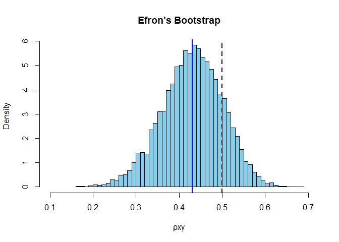

```r
## e)
# Efron's Bootstrap Histogram
hist(bootstrap_r, breaks = "FD", col = "skyblue", main = "Efron's Bootstrap", xlab = "ρxy", xlim=c(0.1,0.7), freq = FALSE)
abline(v = mean(bootstrap_r), col = "blue", lwd = 2)
abline(v = ground_truth, col = "black", lty = 2, lwd = 2)
```

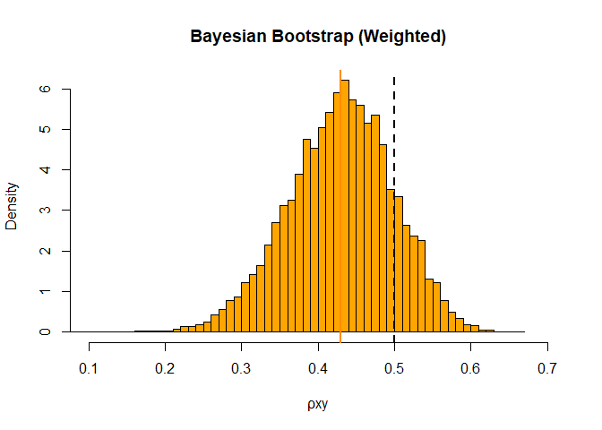

```r
# Bayesian Bootstrap (Weighted) Histogram
hist(rho_bayes1, breaks = "FD", col = "orange", main = "Bayesian Bootstrap (Weighted)", xlab = "ρxy", xlim=c(0.1,0.7), freq = FALSE)
abline(v = mean_rho1, col = "darkorange", lwd = 2)
abline(v = ground_truth, col = "black", lty = 2, lwd = 2)
```

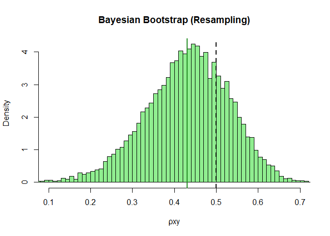

```r
# Bayesian Bootstrap (Resampling) Histogram
hist(rho_bayes2, breaks = "FD", col = "lightgreen", main = "Bayesian Bootstrap (Resampling)", xlab = "ρxy", xlim=c(0.1,0.7), freq = FALSE)
abline(v = mean_rho2, col = "forestgreen", lwd = 2)
abline(v = ground_truth, col = "black", lty = 2, lwd = 2)
```

In general, all the methods give similar level of bias at 0.070, which is inherent due to the original realized sample where all bootstrap samples were generated from. However, the second Bayesian approach gives a larger variance due to the two times of random sample generation, one for $\mathbf{w}$ and once for $(\mathbf{x},\mathbf{y})$. Although all methods should converge to the same solution by Bayeisan CLT, the second Bayesian method has a slower convergence rate. On the other hand, it is interesting that Jackknife method has comparable performance in terms of bias and variance with the first Bayesian method and Efron’s bootstrap method. This is due to the large sample size and the smoothness of the parameter, correlation coefficient.